# Project: reinstatement analysis for high-risk self

Xinyuan Yan

xinyuanyan2016@gmail.com

April 19th, 2021

# About this dataset

**Design**: Rest01----Actual self----Rest02----Ideal self----Rest03----Actual Friend----Ideal Friend----Actual Stranger----Ideal Stranger

**N=27**

**Reference**: [2018 Schapiro et al., NC. Human hippocampal replay during rest prioritizes weakly learned information and predicts memory performance](https://www.nature.com/articles/s41467-018-06213-1)

This notebook will introduce some basic results from **reinstatement analysis**

1. Hamming window (convolution function)

2. Reinstatement for actual self.

3. Reinstatement for ideal self.

4. Imcomplete dataset.....

## Hamming window

Preprocessed resting time series convolved with hamming window (left figure), three-point-width hamming window whose shape most like HRF, if the parameter used 5, 6, 7 but not 3, the shape won’t be like with HRF (right figure). Then transferred the convolved signal to percent signal change.

[figure not shown]

## Reinstatement for actual self.

**ROI information**: all ROIs were 10mm-radius centered on the reported peak voxel from 3-self paper

```python
import numpy as np
import matplotlib.pyplot as plt
import pandas as pd
import seaborn as sns
```

```python
#read the result
rein_actual=pd.read_excel('E:\\22_HighRiskDEP\\5_Analysis_replay_resting_2021\\RESULTS_AC_self_3self_LMFG.xlsx',sheet_name='Sheet1')
```

```python
#show the data
rein_actual
```

|  | subfile | BDI_prescan | 3selfMFG_10--18_30_33 | BDI-V3 | HAMD-V3 |
| --- | --- | --- | --- | --- | --- |
| 0 | '20190118_STIG01_JiangYangjin' | NaN | 0.089916 | 4.000000 | 6.000000 |
| 1 | '20190118_STIG02_WuXue' | NaN | 0.029896 | 12.000000 | 10.000000 |
| 2 | '20190121_P04_MAYN_WDY_SUB03_TR' | NaN | -0.156943 | 21.000000 | 10.000000 |
| 3 | '20190121_P06_MAYN_WDY_SUB05_YSY' | NaN | -0.003366 | 9.000000 | 5.000000 |
| 4 | '20190122_P01_MAYN_WDY_SUB06_GYH' | NaN | 0.185088 | 11.000000 | 4.000000 |
| 5 | '20190122_P05_MAYN_WDY_SUB10_GYY' | NaN | -0.049804 | 34.000000 | 15.000000 |
| 6 | '20190124_P04_MAYN_WDY_ZHANGYAO' | NaN | 0.226267 | 15.000000 | 7.000000 |
| 7 | '20190124_P05_MAYN_WDY_CAOSIYU' | NaN | 0.048263 | 23.000000 | 15.000000 |
| 8 | '20190305_P01_MAYN_WDY_LUOLINGYUE' | NaN | -0.000704 | NaN | NaN |
| 9 | '20190305_P03_MAYN_WDY_HANTING' | NaN | 0.057708 | 19.000000 | 8.000000 |
| 10 | '20190305_P04_MAYN_WDY_LIWENDAN' | NaN | 0.090643 | 1.000000 | 5.000000 |
| 11 | '20190306_P01_MAYN_WDY_XIAOYIFEI' | NaN | 0.197761 | 8.000000 | 4.000000 |
| 12 | '20190306_P02_MAYN_WDY_LIUSIHONG' | NaN | 0.064281 | 14.000000 | 7.000000 |
| 13 | '20190306_P03_MAYN_WDY_TIANRONG' | NaN | -0.015416 | 25.000000 | 4.000000 |
| 14 | '20190306_P04_MAYN_WDY_CHAIZHIQIANG' | NaN | 0.055900 | 3.000000 | 6.000000 |
| 15 | '20190306_P05_MAYN_WDY_JIANGYIHAN' | NaN | -0.184580 | 16.000000 | 7.000000 |
| 16 | '20190307_P01_MAYN_WDY_PANTING' | NaN | -0.022348 | 39.000000 | 27.000000 |
| 17 | '20190307_P02_MAYN_WDY_LIURUOSHUANG' | NaN | 0.143574 | 9.000000 | 10.000000 |
| 18 | '20190307_P03_MAYN_WDY_CHENHAONING' | NaN | 0.198072 | 2.000000 | 2.000000 |
| 19 | '20190307_P04_MAYN_WDY_TANGQIUPING' | NaN | -0.033018 | 17.000000 | 3.000000 |
| 20 | '20190307_P06_MAYN_WDY_WANGXIANGYU' | NaN | 0.210760 | 11.000000 | 2.000000 |
| 21 | '20190310_P01_MAYN_WDY_XUSIQI' | NaN | -0.002087 | 10.000000 | 6.000000 |
| 22 | '20190310_P02_MAYN_WDY_GONGZU' | NaN | 0.016370 | 2.000000 | 2.000000 |
| 23 | '20190310_P03_MAYN_WDY_ZHANGJIE' | NaN | 0.031576 | 7.000000 | 5.000000 |
| 24 | '20190310_P04_MAYN_WDY_ZHENGZIYU' | NaN | 0.005402 | 17.000000 | 12.000000 |
| 25 | '20190310_P05_MAYN_WDY_KANGYUQI' | NaN | 0.040861 | 12.000000 | 1.000000 |
| 26 | '20190310_P06_MAYN_WDY_QINSHUMIN' | NaN | 0.082588 | 13.000000 | 10.000000 |
| 27 | NaN | NaN | NaN | NaN | NaN |
| 28 | NaN | NaN | NaN | NaN | NaN |
| 29 | NaN | NaN | NaN | -0.440592 | -0.307306 |

```python
#valid data
valid_data_LMFG = rein_actual[:27]#get the valid part
print(valid_data_LMFG)
```

```
                                 subfile  BDI_prescan  3selfMFG_10--18_30_33  \
0         '20190118_STIG01_JiangYangjin'          NaN               0.089916
1                '20190118_STIG02_WuXue'          NaN               0.029896
2       '20190121_P04_MAYN_WDY_SUB03_TR'          NaN              -0.156943
3      '20190121_P06_MAYN_WDY_SUB05_YSY'          NaN              -0.003366
4      '20190122_P01_MAYN_WDY_SUB06_GYH'          NaN               0.185088
5      '20190122_P05_MAYN_WDY_SUB10_GYY'          NaN              -0.049804
6       '20190124_P04_MAYN_WDY_ZHANGYAO'          NaN               0.226267
7        '20190124_P05_MAYN_WDY_CAOSIYU'          NaN               0.048263
8     '20190305_P01_MAYN_WDY_LUOLINGYUE'          NaN              -0.000704
9        '20190305_P03_MAYN_WDY_HANTING'          NaN               0.057708
10      '20190305_P04_MAYN_WDY_LIWENDAN'          NaN               0.090643
11     '20190306_P01_MAYN_WDY_XIAOYIFEI'          NaN               0.197761
12     '20190306_P02_MAYN_WDY_LIUSIHONG'          NaN               0.064281
13      '20190306_P03_MAYN_WDY_TIANRONG'          NaN              -0.015416
```

[output cut: 42 more lines]

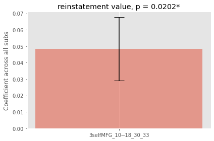

```python
# Build the plot bar

actual_se = np.std(valid_data_LMFG['3selfMFG_10--18_30_33'])/np.sqrt(len(valid_data_LMFG['3selfMFG_10--18_30_33']))
actual_mean = np.mean(valid_data_LMFG['3selfMFG_10--18_30_33'])
materials = ['3selfMFG_10--18_30_33']
x_pos = np.arange(len(materials))
CTEs = [actual_mean]
error = [actual_se]


fig, ax = plt.subplots()
ax.bar(x_pos, CTEs, yerr=error, align='center', alpha=0.5, ecolor='black', capsize=10)
ax.set_ylabel('Coefficient across all subs')
ax.set_xticks(x_pos)
ax.set_xticklabels(materials)
ax.set_title('reinstatement value, p = 0.0202*')
ax.yaxis.grid(False)

# Save the figure and show
plt.tight_layout()
plt.savefig('bar_plot_with_error_bars.png')
plt.show()
```

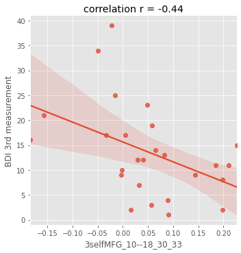

```python
# Build the plot scatter (correlation)


sns.lmplot(x='3selfMFG_10--18_30_33', y='BDI-V3',data = valid_data_LMFG)

plt.title('correlation r = -0.44')
# Set x-axis label
plt.xlabel('3selfMFG_10--18_30_33')
# Set y-axis label
plt.ylabel('BDI 3rd measurement')

plt.show()
```

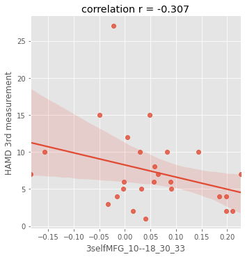

```python
# Build the plot scatter (correlation)


sns.lmplot(x='3selfMFG_10--18_30_33', y='HAMD-V3',data = valid_data_LMFG)

plt.title('correlation r = -0.307')
# Set x-axis label
plt.xlabel('3selfMFG_10--18_30_33')
# Set y-axis label
plt.ylabel('HAMD 3rd measurement')

plt.show()
```

**ROI information**: all ROIs were 10mm-radius centered on the reported peak voxel from 3-self paper

# Imcomplete dataset.....

Imcomplete dataset.....

1. lack full BDI/HAMD scores
2. lack posterior behavioral dataset

util now, the "reinstatement" effect is weak, if necessary to continue to exploring this dataset, need assistance from Chenxiao ^_^